# Structuring a dataset for a meta-analysis

Author

Enrico Toffalini

## Dataset for a meta-analysis of a correlation coefficient

Here is an example of a small meta-analysis dataset coding effect sizes (correlations) from 9 studies encompassing a total of 15 samples.

```
 StudyID yearPub SampleID EffID   corr   n
       1    2017      1_1     1  0.547 171
       2    2024      2_1     2  0.180 452
       2    2024      2_2     3  0.299 245
       3    2017      3_1     4  0.183 399
       4    2019      4_1     5  0.120 445
       5    2019      5_1     6  0.100 230
       5    2019      5_2     7  0.027  69
       6    2017      6_1     8 -0.167 194
       7    2014      7_1     9  0.245 373
       7    2014      7_2    10  0.321 195
       7    2014      7_3    11  0.146 330
       7    2014      7_4    12  0.259 427
       8    2016      8_1    13  0.155 434
       8    2016      8_2    14  0.170 220
       9    2010      9_1    15 -0.266 215
```

*Little but extremely common complication*: Some studies include more than one sample. Luckily, there is a single effect size for each sample (so `SampleID` and `EffID` are practically redundant here). If there were multiple effect sizes for the same sample, you might consider preliminarily aggregating them (unless to-be-aggregated effects are associated with different levels of a moderator of interest, in which case you should keep them separate and add an additional level in a multilevel model; note that this complicates everything a bit because you need to account for correlated sampling error when entering multiple effect sizes from a same group of subjects).

- Step 1: Converting all correlations to Fisher’s z (good for normalizing the distribution, making the variances independent from the effect size, and simplifying subsequent computations):

```r
library(psych)
df$eff = fisherz(df$corr)
```

```
 StudyID yearPub SampleID EffID   corr   n         eff
       1    2017      1_1     1  0.547 171  0.61409036
       2    2024      2_1     2  0.180 452  0.18198269
       2    2024      2_2     3  0.299 245  0.30842106
       3    2017      3_1     4  0.183 399  0.18508488
       4    2019      4_1     5  0.120 445  0.12058103
       5    2019      5_1     6  0.100 230  0.10033535
       5    2019      5_2     7  0.027  69  0.02700656
       6    2017      6_1     8 -0.167 194 -0.16857900
       7    2014      7_1     9  0.245 373  0.25008653
       7    2014      7_2    10  0.321 195  0.33276159
       7    2014      7_3    11  0.146 330  0.14705085
       7    2014      7_4    12  0.259 427  0.26503620
       8    2016      8_1    13  0.155 434  0.15625950
       8    2016      8_2    14  0.170 220  0.17166666
       9    2010      9_1    15 -0.266 215 -0.27255429
```

- Step 2: Compute the effect size variances using the analytical formula:

```r
library(psych)
df$vi = 1 / (df$n - 3)
```

```
 StudyID yearPub SampleID EffID   corr   n         eff          vi
       1    2017      1_1     1  0.547 171  0.61409036 0.005952381
       2    2024      2_1     2  0.180 452  0.18198269 0.002227171
       2    2024      2_2     3  0.299 245  0.30842106 0.004132231
       3    2017      3_1     4  0.183 399  0.18508488 0.002525253
       4    2019      4_1     5  0.120 445  0.12058103 0.002262443
       5    2019      5_1     6  0.100 230  0.10033535 0.004405286
       5    2019      5_2     7  0.027  69  0.02700656 0.015151515
       6    2017      6_1     8 -0.167 194 -0.16857900 0.005235602
       7    2014      7_1     9  0.245 373  0.25008653 0.002702703
       7    2014      7_2    10  0.321 195  0.33276159 0.005208333
       7    2014      7_3    11  0.146 330  0.14705085 0.003058104
       7    2014      7_4    12  0.259 427  0.26503620 0.002358491
       8    2016      8_1    13  0.155 434  0.15625950 0.002320186
       8    2016      8_2    14  0.170 220  0.17166666 0.004608295
       9    2010      9_1    15 -0.266 215 -0.27255429 0.004716981
```

Actually, you could directly use a built-in function named “`escalc`” from the “`metafor`” package itself:

```r
library(metafor)
escalc(measure="ZCOR", ri=corr, ni=n, data=df2)
```

```
   StudyID yearPub SampleID EffID   corr   n      yi     vi
1        1    2017      1_1     1  0.547 171  0.6141 0.0060
2        2    2024      2_1     2  0.180 452  0.1820 0.0022
3        2    2024      2_2     3  0.299 245  0.3084 0.0041
4        3    2017      3_1     4  0.183 399  0.1851 0.0025
5        4    2019      4_1     5  0.120 445  0.1206 0.0023
6        5    2019      5_1     6  0.100 230  0.1003 0.0044
7        5    2019      5_2     7  0.027  69  0.0270 0.0152
8        6    2017      6_1     8 -0.167 194 -0.1686 0.0052
9        7    2014      7_1     9  0.245 373  0.2501 0.0027
10       7    2014      7_2    10  0.321 195  0.3328 0.0052
11       7    2014      7_3    11  0.146 330  0.1471 0.0031
12       7    2014      7_4    12  0.259 427  0.2650 0.0024
13       8    2016      8_1    13  0.155 434  0.1563 0.0023
14       8    2016      8_2    14  0.170 220  0.1717 0.0046
15       9    2010      9_1    15 -0.266 215 -0.2726 0.0047
```

#### Fitting the meta-analytic model

Now, let’s proceed with a simple meta-analytic model… well, not so simple, since it’s random-effects and multilevel!

```r
fit = rma.mv(eff, vi, random =~ 1|StudyID/SampleID, data = df)
summary(fit)
```

```
Multivariate Meta-Analysis Model (k = 15; method: REML)

  logLik  Deviance       AIC       BIC      AICc
  5.7280  -11.4560   -5.4560   -3.5389   -3.0560

Variance Components:

            estim    sqrt  nlvls  fixed            factor
sigma^2.1  0.0557  0.2360      9     no           StudyID
sigma^2.2  0.0011  0.0334     15     no  StudyID/SampleID

Test for Heterogeneity:
Q(df = 14) = 116.4132, p-val < .0001

Model Results:

estimate      se    zval    pval    ci.lb   ci.ub
  0.1340  0.0814  1.6471  0.0995  -0.0255  0.2935  .

---
Signif. codes:  0 '***' 0.001 '**' 0.01 '*' 0.05 '.' 0.1 ' ' 1
```

Heterogeneity across effect sizes is quantified by the two “`sigma`”. The first “`sigma`” represents the estimated heterogeneity across studies, often reported as $\tau$, the second “`sigma`” represents the estimated heterogeneity across samples/effect sizes (within studies), often reported as $\omega$.

#### Forest plot

Now let’s have a look at the forest plot:

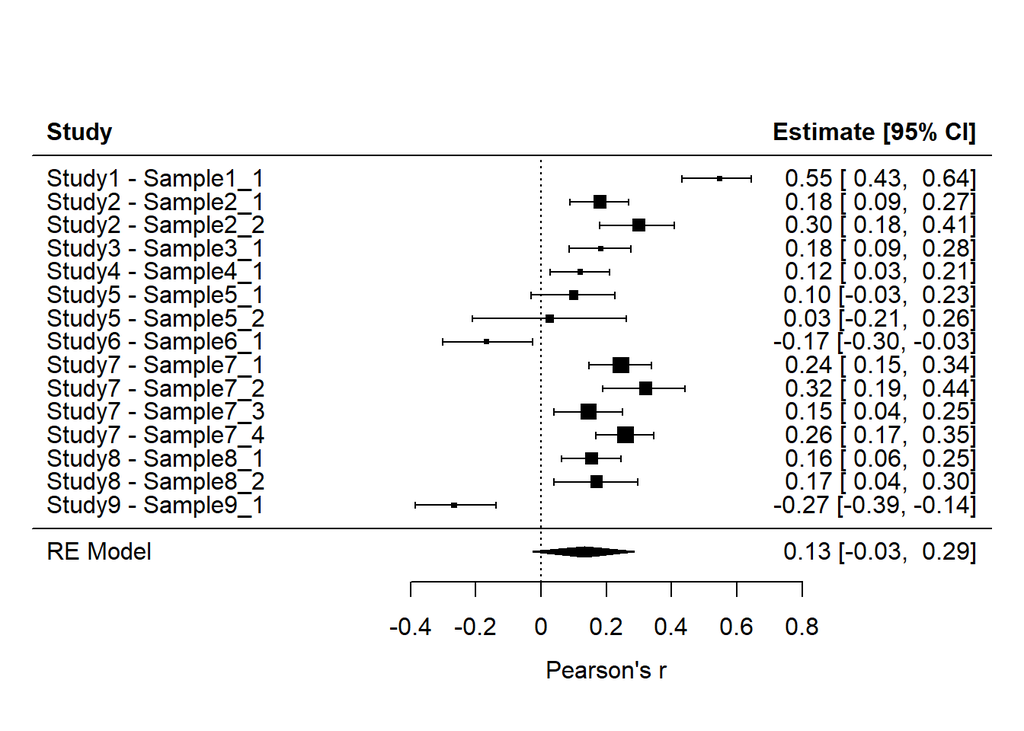

```r
forest(fit,
       slab=paste0("Study",StudyID," - Sample",SampleID),
       header=T,
       transf=psych::fisherz2r,
       xlab="Pearson's r")
```

#### Funnel plot

Routinely, funnel plot is reported for having a look at the distribution of effect sizes while simultaneously considering their variances. This may be the basis for applying methods for checking for publication bias, such as the “trim-and-fill” method… but note that trim-and-fill should NOT be used for multilevel models (as in this case) because it fails to account for the real (multilevel) structure of dependencies across effect sizes.

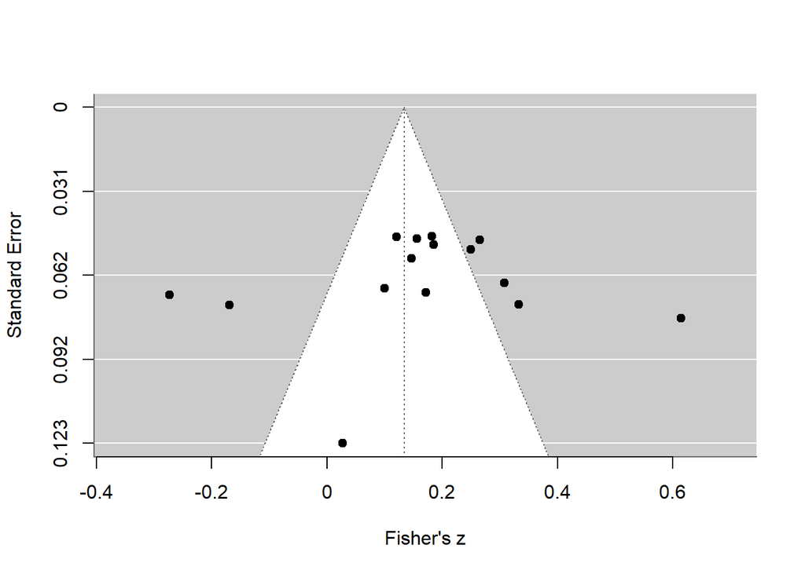

```r
funnel(fit,
       xlab="Fisher's z")
```

Here is a better version of the funnel plot with a meta-regression that takes into account the multilevel structure of the data:

```
[1] Based on the pet-peese procedure, the method used was: pet
[1] The p-value for the pet regression was p = 0.6611
[1] The bias-adjusted effect size was d = 0.08 [95% CI: -0.19, 0.36], p = 0.5495
```

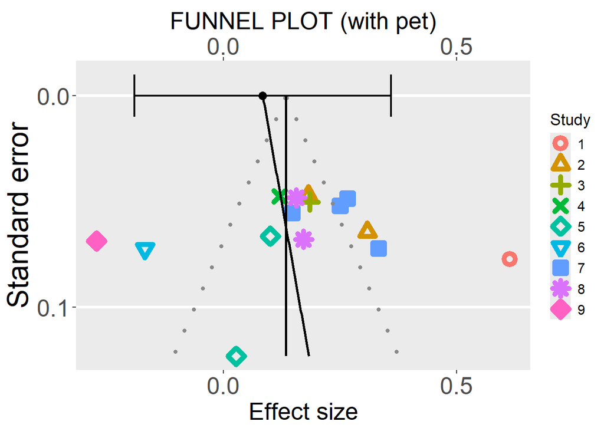

```r
# devtools::install_github("enricotoffalini/toffee")
library(ggplot2)
toffee::funnelT(fit, petpeese="petpeese")
```

#### Meta-regression, just for fun

Let’s add publication year (numerical) as a possible moderator:

```r
fit1 = rma.mv(eff, vi, random =~ 1|StudyID/SampleID, mods =~ yearPub, data = df)
summary(fit1)
```

```
Multivariate Meta-Analysis Model (k = 15; method: REML)

  logLik  Deviance       AIC       BIC      AICc
  6.1301  -12.2601   -4.2601   -2.0003    0.7399

Variance Components:

            estim    sqrt  nlvls  fixed            factor
sigma^2.1  0.0541  0.2325      9     no           StudyID
sigma^2.2  0.0011  0.0336     15     no  StudyID/SampleID

Test for Residual Heterogeneity:
QE(df = 13) = 111.1710, p-val < .0001

Test of Moderators (coefficient 2):
QM(df = 1) = 1.2922, p-val = 0.2556

Model Results:

         estimate       se     zval    pval      ci.lb    ci.ub
intrcpt  -51.0046  44.9865  -1.1338  0.2569  -139.1765  37.1672
yearPub    0.0254   0.0223   1.1368  0.2556    -0.0184   0.0691

---
Signif. codes:  0 '***' 0.001 '**' 0.01 '*' 0.05 '.' 0.1 ' ' 1
```

Comments? What would you say about:

- Have the heterogeneity estimates (“`sigma`”) changed? (if moderators are useful, heterogeneity should be reduced)
- How do you establish the relevance of the moderators?
- How do you interpret the coefficients in “`Model Results`”?

Finally, here is the easiest way for plotting meta-regression:

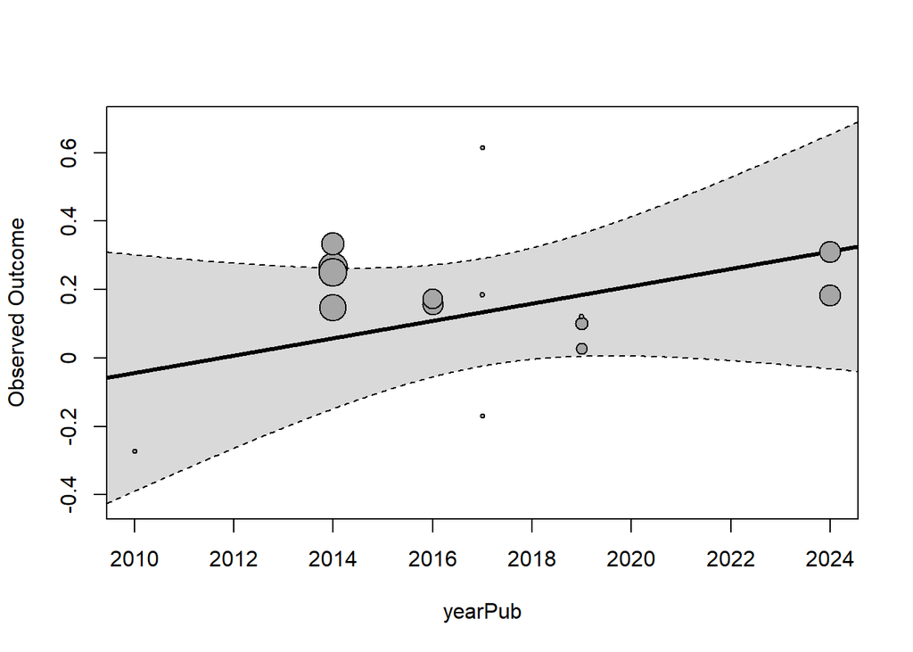

```r
regplot(fit1)
```